# Checking functions for GC Project

Gwen Eadie

15/07/2020

## Introduction

Our goal is to estimate the mass and cumulative mass profile of a globular cluster (GC) using the kinematic information (position and velocity) of its stars and assuming a physical model for the GC.

A Bayesian framework has at least four main advantages for this type of analysis. First, we wish to incorporate useful prior information about GCs to help constrain parameters estimates. Second, kinematic data for GCs is often incomplete and a Bayesian framework allows us to include both incomplete and complete data simultaneously. Third, astronomical data are also subject to measurement uncertainties that are well understood by astronomers, and that we can incorporate via a hierarchical Bayesian framework. Fourth, our ultimate goal is to infer the cumulative mass profile without having to make assumptions about the mass-to-light ratio of the GC, and this should be achievable given samples from the posterior distribution of model parameters.

## Simulated Data

The first step towards our goal is to develop and test our method on simulated GC data. In this initial phase, we use complete data and assume there is no measurement uncertainty. We are also going to work in the reference frame of the GC, where positions and velocities of individual stars are given with respect to the GC center. Ultimately, however, our goal is to work in projected space on the plane of the sky (i.e., the reference frame in which actual data are measured), incorporate measurement uncertainty, and account for incomplete data.

## Likelihood and Model Parameters

The likelihood is defined by a Distribution Function (DF), $f(x|\mathbf{\theta})$ of a lowered-isothermal model given some model parameters $\mathbf{\theta}$ and the total mass $M$ of the GC:
$$\mathcal{L(}x|\theta) = \frac{f(x|\mathbf{\theta})}{M}.$$
For lowered-isothermal models, the DF $f(x|\mathbf{\theta})$ must be calculated numerically via a Python package called LIMEPY, and thus the likelihood must be calculated numerically too. For the DF, we are exploring two separate cases: (1) when all stars in the GC are assumed to be bound (i.e., the LIMEPY model DF), and (2) when some stars are allowed to be “potential escapers” (referred to as the SPES model DF).

The LIMEPY and SPES models have four and five parameters respectively:
$$\text{LIMEPY}\rightarrow \mathbf{\theta} = (g, \Phi_0, M, r_h)\\
\text{SPES}\rightarrow \mathbf{\theta} = (\Phi_0, B, \eta, M, r_h)$$

In both LIMEPY and SPES, $M$ is the total mass and $r_h$ is the half-light radius of the GC. In LIMEPY, $g$ determines the spatial distribution of stars and $\Phi_0$ determines the gravitational potential of the GC. In SPES, $\Phi_0$ determines the gravitational potential of the GC, and $B$ and $\eta$ somehow determine how many “escapers” there are in the GC (and maybe their spatial distribution? I’m still fuzzy on the physical interpretation of these parameters).

For our intial tests, we use simulated kinematic data of stars following a LIMEPY model DF with parameters $\mathbf{\theta}$. We assume the LIMEPY DF for the likelihood and define informative priors on the model parameters. Given that the DF and the data follow the same model, we expect to obtain reasonable parameter estimates for the total mass $M$ through estimation of the posterior distribution using MCMC. After this, we will perform the same exercise with the simulated LIMEPY data but instead assume an SPES model for the likelihood. In the latter case, we are less sure how well the model will estimate the physical parameters.

## Prior Distributions on $\mathbf{\theta}$

In order for a DF to correspond to physically realistic GC, all model parameters must be greater than zero. In the SPES model, $B$ and $\eta$ are also restricted between $0$ and $1$ to be physically meaningful.

Images and studies of GCs both within the Milky Way Galaxy and around other galaxies provide informative priors on things like the mass and half-light radius. GC masses span about an order of magnitude; astronomers tend to think in terms of $log_{10}M$ for GC masses, and would be comfortable setting the prior
$$p(\log_{10}M) \sim N(\mu, \sigma^2)$$
where the hyperparamters $\mu$ and $\sigma$ are defined in $\log_{10}M$. Our LIMEPY and SPES models, however, work in $M$ space, so we need to do a change of variables to obtain the prior $p(M)$. Let $\phi = h(M) = \log_{10}M$, then $p(\phi)\equiv p(\log_{10}M)$. We can use a change of variables to find $p(M)$:
$$p(\phi) = p(M) \frac{dM}{d\phi} \\
\rightarrow p(M) = \frac{p(\phi)}{\frac{dM}{d\phi}}$$
where $\frac{dM}{d\phi} = 10^{\phi}\ln10$. Therefore, $$
$$\begin{align}
p(M) &= \frac{p(\phi)}{10^{\phi}\ln10} \\
&= \frac{p(\log_{10}M)}{10^{\log_{10}M}\ln10} \\
p(M) &= \frac{N(\mu,\sigma)}{M\ln10}
\end{align}$$
$$

The functions for these priors are defined in the functions_priors.r file.

```r
source("../RScripts/function_priors.r")

ls()
```

```
## [1] "gaus.prior"       "lnorm.prior"      "normlog10M.prior"
## [4] "singleunif.prior" "truncnorm.prior"
```

```r
# Note that it includes a couple other functions too. We are using singleunif.prior, normlog10M.prior, and truncnorm.prior here, shown in more detail below:

# uniform prior
singleunif.prior
```

```
## function (pars, ppars)
## {
##     par.min = ppars[1]
##     par.max = ppars[2]
##     if (par.min == par.max) {
##         priorvalue = 1
##     }
##     else {
##         priorvalue = 1/(par.max - par.min) * (par.min <= pars &
##             pars <= par.max)
##     }
##     priorvalue
## }
```

```r
# prior on log_10(M)
normlog10M.prior
```

```
## function (pars, ppars)
## {
##     if (pars <= 0) {
##         return(0)
##     }
##     else {
##         dnorm(x = log10(pars), mean = ppars[1], sd = ppars[2])/(pars *
##             log(10))
##     }
## }
```

```r
# truncated normal prior
truncnorm.prior
```

```
## function (pars, ppars)
## {
##     dtruncnorm(x = pars, a = ppars[1], b = ppars[2], mean = ppars[3],
##         sd = ppars[4])
## }
```

```r
gbounds = c(1e-3, 3.5) # bounds for uniform prior on g
phi0bounds = c(1.5, 14) # bounds for uniform prior on phi_0
log10Mpars = c( 5.85, 0.6 ) # mean and standard deviation for log10(M)
rhpars = c(0, 30, 3.0, 0.2) # lower bound, upper bound, mean, sd for r_h
```

Now let’s plot the priors to check them.

### prior on $g$

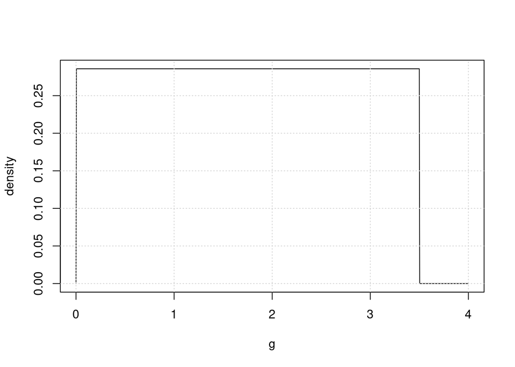

```r
curve(expr = singleunif.prior(x, ppars = gbounds), from = 0, to = 4, n=1e3, ylab="density", xlab="g")
grid()
```

### prior on $\Phi_0$

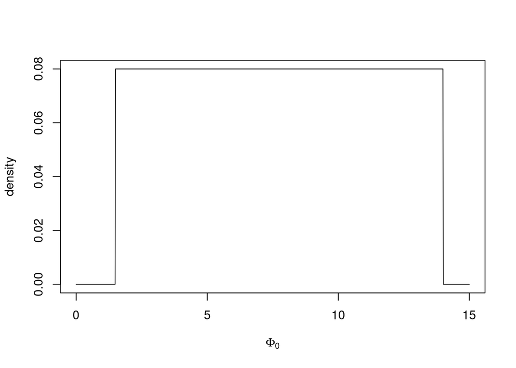

```r
curve( singleunif.prior(x, ppars = phi0bounds), from=0, to=15, n=1e3, ylab="density", xlab=expression(Phi[0]))
```

### prior on $\log_{10} M$:

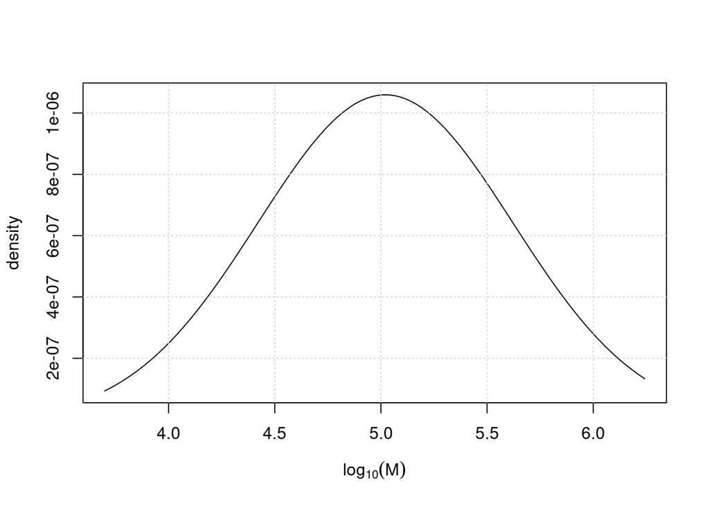

```r
library(emdbook)
Mvalues = lseq(from = 0.5e4, to = 1.75e6, length.out = 1e3)

plot(x = log10(Mvalues), y = sapply(X = Mvalues, FUN = normlog10M.prior, ppars = log10Mpars), type="l", xlab=expression(log[10](M)), ylab="density", )
grid()
```

*Does this look right? This will allow for very massive globular clusters. Let’s look at it in regular M space…*

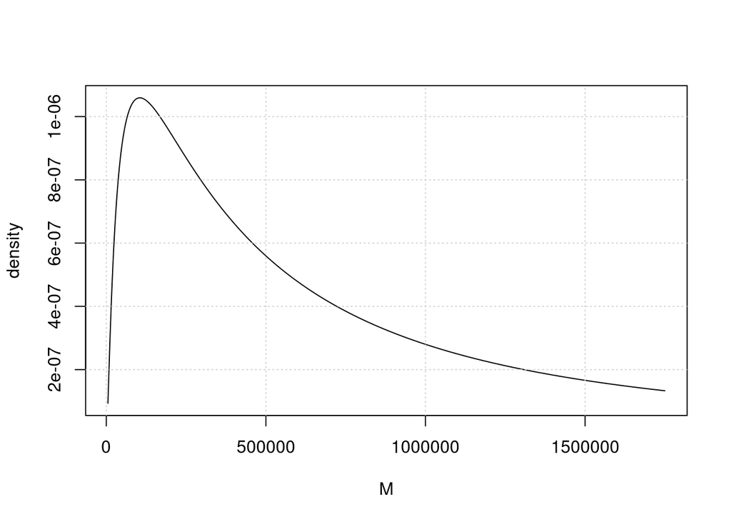

```r
library(emdbook)
plot(x = Mvalues, y = sapply(X = Mvalues, FUN = normlog10M.prior, ppars = log10Mpars), type="l", xlab="M", ylab="density")
grid()
```

### prior on $r_h$

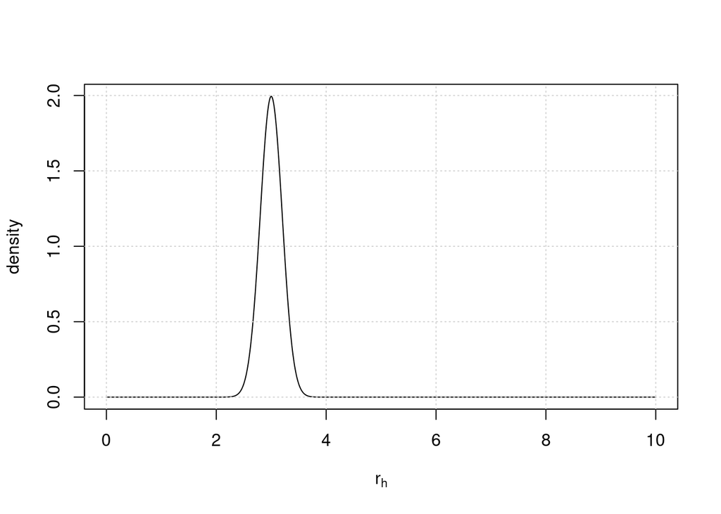

```r
curve(expr = truncnorm.prior(pars = x, ppars = rhpars), from = 0, to = 10, n=1e3, ylab = "density", xlab = expression(r[h]))
grid()
```

This looks correct — we set quite a narrow prior on $r_h$ because in the case of a real Globular cluster, we would be able to obtain a prior distribution on $r_h$ from image analysis.

I have also written a function called prior.wrapper that puts all the priors together into a single call, shown and demonstrated below.

```r
source('../RScripts/function_prior-wrapper.r')
prior.wrapper
```

```
## function (pars, priorfuncs, ppars, ...)
## {
##     if (length(priorfuncs) != length(pars)) {
##         stop("Error: number of prior functions doesn't match number of parameters")
##     }
##     priorvalues = rep(NA, length = length(pars))
##     for (i in 1:length(pars)) {
##         priorvalues[i] = priorfuncs[[i]](pars[i], ppars[[i]])
##     }
##     priorvalues
## }
```

```r
# some test parameters for g, phi0, M, and rh
gtest = 1.5
phi0test = 6.1
Mtest = 1.2e5
rhtest = 3.1
testpars = c(gtest, phi0test, Mtest, rhtest)

# Test the prior wrapper
prior.wrapper(pars = testpars, priorfuncs = list(singleunif.prior, singleunif.prior, normlog10M.prior, truncnorm.prior), ppars = list(gbounds, phi0bounds, log10Mpars, rhpars))
```

```
## [1] 2.857959e-01 8.000000e-02 1.054318e-06 1.760327e+00
```

Note that these are the same values as if you called the prior functions individually.

```r
singleunif.prior(pars = testpars[1], ppars = gbounds)
```

```
## [1] 0.2857959
```

```r
singleunif.prior(pars = testpars[2], ppars = phi0bounds)
```

```
## [1] 0.08
```

```r
normlog10M.prior(pars = testpars[3], ppars = log10Mpars)
```

```
## [1] 1.054318e-06
```

```r
truncnorm.prior(pars = testpars[4], ppars = rhpars)
```

```
## [1] 1.760327
```

prior.wrapper will be used later when evaluating the log-target density.

## Testing the log-likelihood function for the LIMEPY model

The MCMC code takes in a function for the log-likelihood. In the case of the LIMEPY model, the likelihood function is named logLike.limepy, shown below.

```r
# source the log-likelihood function
source("../RScripts/function_logLike_LIMEPY.r")
logLike.limepy
```

```
## function (pars, dat, transform.pars = NULL, pot = NULL, DF = NULL)
## {
##     if (!is.null(transform.pars)) {
##         pars = transform.pars(pars)
##     }
##     if (any(pars < 0)) {
##         return(rep(-Inf, nrow(dat)))
##     }
##     lmodel = try(limepy$limepy(g = pars[1], phi0 = pars[2], M = pars[3],
##         rh = pars[4]), silent = TRUE)
##     if (any(class(lmodel) == "try-error")) {
##         output = rep(-Inf, nrow(dat))
##     }
##     else {
##         output = try(log((lmodel$df(dat$r, dat$v))/pars[3]),
##             silent = TRUE)
##         if (any(class(output) == "try-error")) {
##             output = rep(-Inf, nrow(dat))
##         }
##     }
##     output
## }
```

Next, I focus on the line which numerically calculates the DF in the logLike.limepy function. For this example I use a small ($n=10$) sample of simulated data.

```r
# load the simulated data for testing
alldata = readRDS("../mockdata/snap_version2_dffix_2020-03-09.rds")
# get a random sample of the stars
nsamp = 10
set.seed(123)
smalldata = alldata[sample(x = 1:nrow(alldata), size = nsamp, replace = FALSE), ]

# what does the data frame look like?
str(smalldata)
```

```
## 'data.frame':    10 obs. of  2 variables:
##  $ r: num  1.2 5.44 3.22 4.91 1.97 ...
##  $ v: num  12.31 8.84 5.55 6.93 4.69 ...
```

```r
# these are the true parameter values that were used to create simulated data
truepars <- c(1.4, 5.,125892.,3.1)

# numerically obtain the LIMEPY DF given by the test parameter values defined earlier
LIMEPYdf = limepy$limepy(g = testpars[1], phi0 = testpars[2], M=testpars[3], rh=testpars[4])

# now try using this model with the mock data to calculate the DF at the data points
LIMEPYdf$df( smalldata$r, smalldata$v )
```

```
##  [1] 0.0542998579 0.0026572188 0.0336154665 0.0078455817 0.1254310705
##  [6] 0.0347042321 0.0581852608 0.0006270377 0.0017358933 0.4386640995
```

This looks like it is working OK. What if I pass it bad parameter values?

```r
badpars = c(0.1,2.1, 100, -3.4)

badLIMEPYdf = limepy$limepy(g = badpars[1], phi0 = badpars[2], M=badpars[3], rh=badpars[4])

# now try using this model with the mock data to calculate the DF at the data points
badLIMEPYdf$df( smalldata$r, smalldata$v )
```

```
## Error in py_call_impl(callable, dots$args, dots$keywords): ValueError: x coordinates are not in increasing order
##
## Detailed traceback:
##   File "/usr/local/lib/python3.7/site-packages/astro_limepy-0.1.1-py3.7.egg/limepy/limepy.py", line 1117, in df
##     phi = self.interp_phi(r)
##   File "/usr/local/lib/python3.7/site-packages/astro_limepy-0.1.1-py3.7.egg/limepy/limepy.py", line 1064, in interp_phi
##     if (not self._interpolator_set): self._setup_phi_interpolator()
##   File "/usr/local/lib/python3.7/site-packages/astro_limepy-0.1.1-py3.7.egg/limepy/limepy.py", line 806, in _setup_phi_interpolator
##     self._phi_poly = BPoly.from_derivatives(self.r,phi_and_derivs)
##   File "/usr/local/lib/python3.7/site-packages/scipy-1.3.1-py3.7-linux-x86_64.egg/scipy/interpolate/interpolate.py", line 1709, in from_derivatives
##     raise ValueError("x coordinates are not in increasing order")
```

We receive an error from the Python code. Will come back to this in a minute. In the meantime, let’s go back to the model that had reasonable $\mathbf{\theta}$ values and calculate the likelihood at the data points. The likelihood is the DF divided by the total mass M, so this would give us

```r
LIMEPYdf$df( smalldata$r, smalldata$v )/testpars[3]
```

```
##  [1] 4.524988e-07 2.214349e-08 2.801289e-07 6.537985e-08 1.045259e-06
##  [6] 2.892019e-07 4.848772e-07 5.225314e-09 1.446578e-08 3.655534e-06
```

and a log-likelihood value of

```r
log( LIMEPYdf$df( smalldata$r, smalldata$v )/testpars[3] )
```

```
##  [1] -14.60848 -17.62572 -15.08802 -16.54305 -13.77125 -15.05614 -14.53937
##  [8] -19.06975 -18.05148 -12.51927
```

Is this what our function logLike.limepy() returns?

```r
logLike.limepy(pars = testpars, dat = smalldata)
```

```
##  [1] -14.60848 -17.62572 -15.08802 -16.54305 -13.77125 -15.05614 -14.53937
##  [8] -19.06975 -18.05148 -12.51927
```

Yes. Good!

How does my function deal with the bad parameter values?

```r
logLike.limepy(pars = badpars, dat = smalldata)
```

```
##  [1] -Inf -Inf -Inf -Inf -Inf -Inf -Inf -Inf -Inf -Inf
```

```r
lessobviousbadpars = c(1.5, 1.5, 1e5, 0.1)

logLike.limepy(pars = lessobviousbadpars, dat=smalldata)
```

```
##  [1] -Inf -Inf -Inf -Inf -Inf -Inf -Inf -Inf -Inf -Inf
```

## Running optim on the log target distribution

Now I will run an optimizer on the log-target distribution (log-likelihood plus log-priors) to see if it is reasonable to find a maximum in parameter space given our simulated data. Let’s use more data ($n=500$) this time.

```r
# get a random sample of the stars
nsamp = 500
set.seed(123)
mydata = alldata[sample(x = 1:nrow(alldata), size = nsamp, replace = FALSE), ]

# write a function to calculate the target density
targetdensity <- function(init, mydat, logLike, priors=prior.wrapper, ... ){

  if( any( !is.finite(log(priors(pars = init, ...)))) ){ return(-Inf)}

  sum( logLike( pars=init, dat=mydat ) ) + sum( log( priors( pars = init, ... ) ) )
}


# run optim
test = optim(par = testpars, fn = targetdensity, mydat = mydata, logLike = logLike.limepy, priorfuncs = list(singleunif.prior, singleunif.prior, normlog10M.prior, truncnorm.prior), ppars = list( gbounds, phi0bounds, log10Mpars, rhpars), control=list(fnscale=-1) )

print(test)
```

```
## $par
## [1] 1.278581e+00 6.055939e+00 1.248602e+05 3.002169e+00
##
## $value
## [1] -7886.123
##
## $counts
## function gradient
##      169       NA
##
## $convergence
## [1] 0
##
## $message
## NULL
```

It’s a good idea to run optim again from these final parameter values, to double check the result

```r
test2 = optim(par = test$par, fn = targetdensity, mydat = mydata, logLike = logLike.limepy, priorfuncs = list(singleunif.prior, singleunif.prior, normlog10M.prior, truncnorm.prior), ppars = list( gbounds, phi0bounds, log10Mpars, rhpars), control=list(fnscale=-1) )

print(test2)
```

```
## $par
## [1] 1.273596e+00 6.057375e+00 1.251523e+05 3.005306e+00
##
## $value
## [1] -7886.116
##
## $counts
## function gradient
##      147       NA
##
## $convergence
## [1] 0
##
## $message
## NULL
```

```r
saveRDS(test2, file = paste0("../results/optim_LIMEPYdata_LIMEPYmodel", Sys.Date(), ".rds"))
```

It looks OK, the results barely changed and I think the parameter estimates look reasonable?

I also performed a grid search using the following code (not run here, because it’s computationally expensive).

```r
# make grid of parameter values
griddim = 25
gseq = seq(1e-1, 3.49, length.out=griddim)
phi0seq = seq(1.5, 14, length.out = griddim)
Mseq = seq(1e5, 1.5e5, length.out = griddim)
rhseq = seq(1e-2, 30, length.out = griddim)

pargrid = expand.grid(g = gseq, phi0 = phi0seq, M = Mseq, rh = rhseq)

targetvalues <- apply(X = pargrid, FUN = targetdensity, MARGIN = 1, mydat = mydata, logLike = logLike.limepy, priorfuncs = list(singleunif.prior, singleunif.prior, normlog10M.prior, truncnorm.prior), ppars = list( gbounds, phi0bounds, log10Mpars, rhpars))

saveRDS(targetvalues, file = paste0("../results/gridsearch_", Sys.Date(), ".rds") )
```

I will load the results here and show the surface of the log-target density values in a conditional plot that focuses on the $M$ and $r_h$ grid.

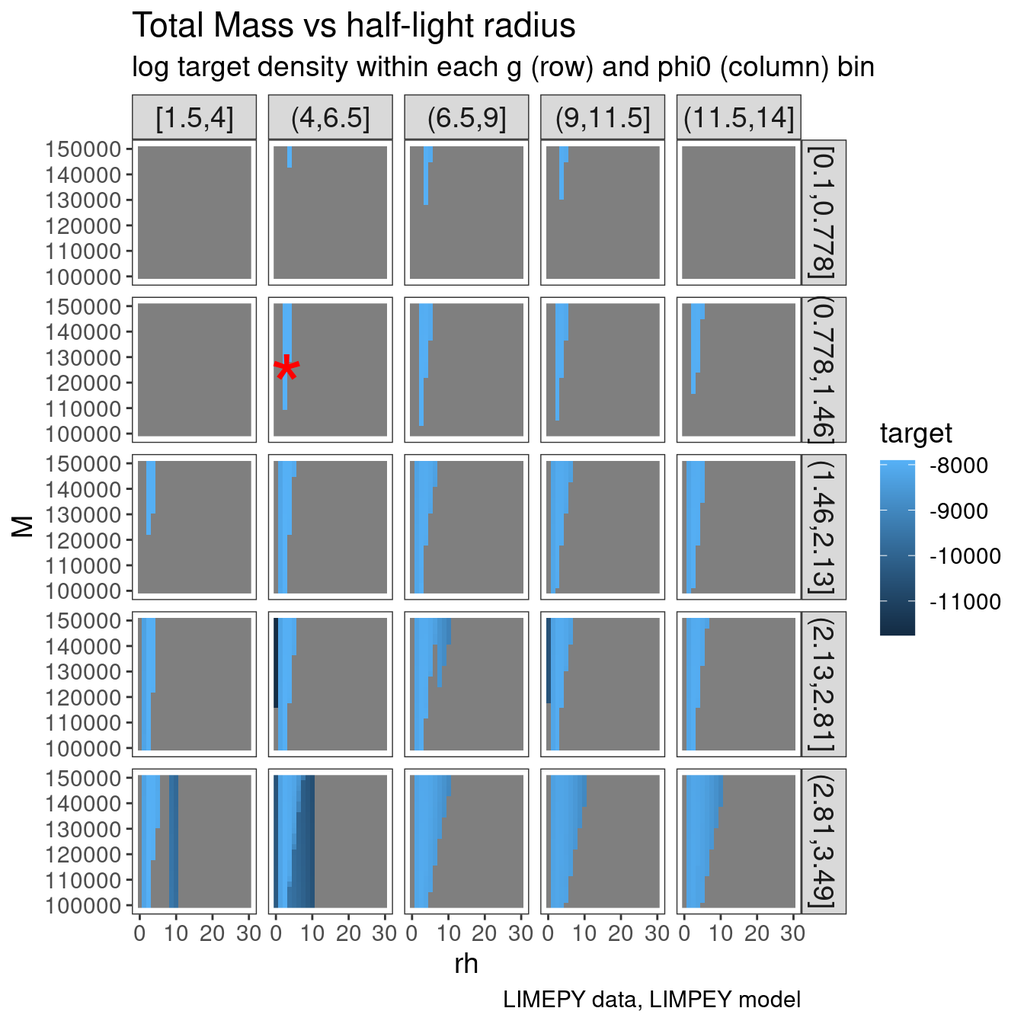

```r
library(ggplot2)
library(dplyr)

# set-up parameter grid
griddim = 25
gseq = seq(1e-1, 3.49, length.out=griddim)
phi0seq = seq(1.5, 14, length.out = griddim)
Mseq = seq(1e5, 1.5e5, length.out = griddim)
rhseq = seq(1e-2, 30, length.out = griddim)

pargrid = expand.grid(g = gseq, phi0 = phi0seq, M = Mseq, rh = rhseq)

# the grid search is computationally expensive and done prior to this.
# Load the resulting target density from the grid search

# gridsearch using r_h prior centered on 3.4
target34 <- readRDS("../results/gridsearch_2020-07-08")

# gridsearch using r_h prior centered on 3.0
target <- readRDS("../results/gridsearch_2020-08-02.rds")

# add the the dataframe
pargrid$target = target

# replace -Inf with NAs for plotting purposes
pargrid$target <- na_if(x = pargrid$target, y = -Inf)

# add a row to the end of the dataframe with the true values
pargrid2 <- add_row(.data = pargrid, g=truepars[1], phi0=truepars[2], M=truepars[3], rh=truepars[4])

# for plotting as a conditional plot, place target values into 5 bins in g and 5 bins in phi0
conditional = mutate(pargrid2, gbin = ggplot2::cut_interval(x = pargrid2$g, n = 5) ) %>%
  mutate(phi0bin = ggplot2::cut_interval(x = pargrid2$phi0, n=5))

trueval <- conditional[nrow(conditional), ]

conditional <- conditional[-nrow(conditional), ] %>%
  group_by(M, rh, gbin, phi0bin) %>% # then group by these bins, M, and r_h
      summarize(target = mean(target, na.rm = TRUE)) # and for every M and r_h, take the mean log target for every g and phi_0 combination

# make the base plot
g <- ggplot(data = conditional, aes(x=rh, y=M, fill=target)) +
  geom_raster()

# make a conditional plot by binning the results
g +
  facet_grid( gbin ~ phi0bin ) +
  labs(title="Total Mass vs half-light radius", caption = "LIMEPY data, LIMPEY model", subtitle="log target density within each g (row) and phi0 (column) bin") +
  theme_bw() + theme(strip.text = element_text(size = 14), text = element_text(size=14), panel.grid.major = element_blank(), panel.grid.minor = element_blank()) +
  geom_point(data = trueval, color="red", shape="*", size=15)
```

This surface looks slightly problematic from a sampling perspetive.

This is very different from optim’s result using the same set of data!

```r
# the parameter order here is g, phi_0, M, and r_h
print(test2)
```

```
## $par
## [1] 1.273596e+00 6.057375e+00 1.251523e+05 3.005306e+00
##
## $value
## [1] -7886.116
##
## $counts
## function gradient
##      147       NA
##
## $convergence
## [1] 0
##
## $message
## NULL
```

I’m quite confused by this… some things to try:

- re-run the grid search around the maximum found by optim
- run the Markov chain starting at the maximum found by optim

# LIMPEY Data, SPES model assumption

Now let’s set up the SPES likelihood function.

```r
source("../RScripts/function_logLike_SPES.r")
logLike.spes
```

```
## function (pars, dat, transform.pars = NULL)
## {
##     if (!is.null(transform.pars)) {
##         pars = transform.pars(pars)
##     }
##     if (any(pars < 0)) {
##         return(rep(-Inf, nrow(dat)))
##     }
##     lmodel = try(limepy$spes(phi0 = pars[1], B = pars[2], eta = pars[3],
##         M = pars[4], rh = pars[5]), silent = TRUE)
##     if (any(class(lmodel) == "try-error")) {
##         output = rep(-Inf, nrow(dat))
##     }
##     else {
##         output = try(log((lmodel$df(dat$r, dat$v))/pars[4]),
##             silent = TRUE)
##         if (any(class(output) == "try-error")) {
##             output = rep(-Inf, nrow(dat))
##         }
##     }
##     output
## }
```

Next, I focus on the line which numerically calculates the DF in the logLike.spes function. For this example I use a small ($n=10$) sample of simulated data.

```r
# use the small sample of data that we used earlier
smalldata
```

```
##                r         v
## 51663   1.198354 12.307141
## 57870   5.435460  8.838588
## 2986    3.220208  5.545605
## 29925   4.908580  6.925447
## 95246   1.972823  4.690225
## 103065  1.060881 13.960766
## 68293   2.703459  4.853456
## 62555  14.526934  3.502973
## 45404   8.564575  5.961961
## 65161   0.837526  6.114846
```

```r
# SPES takes in a different order for the parameters than LIMEPY
# SPES order is phi0, B, eta, M, rh
Btest = 0.5
etatest = 0.5
SPEStestpars = c(phi0test, Btest, etatest, Mtest, rhtest)

# numerically obtain the SPES DF given by the test parameter values defined earlier
SPESdf = limepy$spes(phi0 = SPEStestpars[1], B = SPEStestpars[2], eta = SPEStestpars[3], M = SPEStestpars[4], rh= SPEStestpars[5])

# now try using this model with the mock data to calculate the DF at the data points
SPESdf$df( smalldata$r, smalldata$v )
```

```
##  [1] 0.0502507901 0.0033048006 0.0349262889 0.0095305885 0.1222552265
##  [6] 0.0325633236 0.0582254623 0.0007536718 0.0016143785 0.4188674754
```

Out of curiousity, how different are these form the LIMEPY DF values?

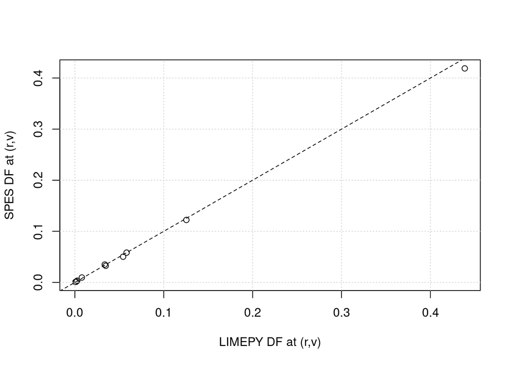

```r
plot(LIMEPYdf$df( smalldata$r, smalldata$v ), SPESdf$df(smalldata$r, smalldata$v), xlab="LIMEPY DF at (r,v)", ylab="SPES DF at (r,v)")
grid()
abline(0,1,lty=2)
```

My function logLike.SPES should return the same values as the following

```r
log(SPESdf$df( smalldata$r, smalldata$v )/SPEStestpars[4])
```

```
##  [1] -14.68598 -17.40763 -15.04976 -16.34850 -13.79689 -15.11982 -14.53868
##  [8] -18.88580 -18.12405 -12.56545
```

```r
logLike.spes(pars = SPEStestpars, dat = smalldata)
```

```
##  [1] -14.68598 -17.40763 -15.04976 -16.34850 -13.79689 -15.11982 -14.53868
##  [8] -18.88580 -18.12405 -12.56545
```

Great! Those match. How does my function deal with bad parameter values?

```r
badSPESpars = c(0.1,0.09, 0.99, 100.0, -3.4)

logLike.spes(pars = badSPESpars, dat = smalldata)
```

```
##  [1] -Inf -Inf -Inf -Inf -Inf -Inf -Inf -Inf -Inf -Inf
```

## Optim run: LIMEPY data, SPES model assumption

We need to set the hyperparameters for $B$ and $\eta$, which will have uniform priors.The other hyperparameters will stay the same.

```r
Bbounds = c(0,1)
etabounds = c(0,1)

# check that starting values are OK
targetdensity(init = SPEStestpars, mydat = mydata, logLike = logLike.spes, priorfuncs = list(singleunif.prior, singleunif.prior, singleunif.prior, normlog10M.prior, truncnorm.prior), ppars = list( phi0bounds, Bbounds, etabounds, log10Mpars, rhpars))


# # run this if you want to see the parameters and targetdensity values as optim runs
# wrap_f <- function(par, mydat, logLike, priors = prior.wrapper, ...){
#     cat(par, "\n",  targetdensity(par, mydat, logLike, priors, ... ), "\n")
#     targetdensity(par, mydat, logLike, priors, ... )
# }

# test = optim(par = SPEStestpars, fn = wrap_f, control=list(fnscale=-1), mydat = mydata, logLike = logLike.spes,  ppars = list( phi0bounds, Bbounds, etabounds, log10Mpars, rhpars), priorfuncs = list(singleunif.prior, singleunif.prior, singleunif.prior, normlog10M.prior, truncnorm.prior))

# run optim
test = optim(par = SPEStestpars, fn = targetdensity, mydat = mydata, logLike = logLike.spes, priorfuncs = list(singleunif.prior, singleunif.prior, singleunif.prior, normlog10M.prior, truncnorm.prior), ppars = list( phi0bounds, Bbounds, etabounds, log10Mpars, rhpars), control=list(fnscale=-1))

# run again just to be safe
test2 = optim(par = test$par, fn = targetdensity, mydat = mydata, logLike = logLike.spes, priorfuncs = list(singleunif.prior, singleunif.prior, singleunif.prior, normlog10M.prior, truncnorm.prior), ppars = list( phi0bounds, Bbounds, etabounds, log10Mpars, rhpars), control=list(fnscale=-1))

# still hasn't stabilized
test3 = optim(par = test2$par, fn = targetdensity, mydat = mydata, logLike = logLike.spes, priorfuncs = list(singleunif.prior, singleunif.prior, singleunif.prior, normlog10M.prior, truncnorm.prior), ppars = list( phi0bounds, Bbounds, etabounds, log10Mpars, rhpars), control=list(fnscale=-1))

# wow this is taking awhile
test4 = optim(par = test3$par, fn = targetdensity, mydat = mydata, logLike = logLike.spes, priorfuncs = list(singleunif.prior, singleunif.prior, singleunif.prior, normlog10M.prior, truncnorm.prior), ppars = list( phi0bounds, Bbounds, etabounds, log10Mpars, rhpars), control=list(fnscale=-1))

# again!!
test5 = optim(par = test4$par, fn = targetdensity, mydat = mydata, logLike = logLike.spes, priorfuncs = list(singleunif.prior, singleunif.prior, singleunif.prior, normlog10M.prior, truncnorm.prior), ppars = list( phi0bounds, Bbounds, etabounds, log10Mpars, rhpars), control=list(fnscale=-1))

# maybe it's good now?
test6 = optim(par = test5$par, fn = targetdensity, mydat = mydata, logLike = logLike.spes, priorfuncs = list(singleunif.prior, singleunif.prior, singleunif.prior, normlog10M.prior, truncnorm.prior), ppars = list( phi0bounds, Bbounds, etabounds, log10Mpars, rhpars), control=list(fnscale=-1))

# ok it looks more stable now
test7 = optim(par = test6$par, fn = targetdensity, mydat = mydata, logLike = logLike.spes, priorfuncs = list(singleunif.prior, singleunif.prior, singleunif.prior, normlog10M.prior, truncnorm.prior), ppars = list( phi0bounds, Bbounds, etabounds, log10Mpars, rhpars), control=list(fnscale=-1))

# good enough!
saveRDS(test7, paste0("../results/optim_LIMEPYdata_SPESmodel", ".rds") )
```

What are the optimal parameter values?

```r
optimvals <- readRDS('../results/optim_LIMEPYdata_SPESmodel.rds')
optimvals
```

```
## $par
## [1] 2.088545e+00 1.299654e-04 9.667572e-01 1.258708e+05 2.396761e-01
##
## $value
## [1] -5977.777
##
## $counts
## function gradient
##      501       NA
##
## $convergence
## [1] 1
##
## $message
## NULL
```

The parameter estimates from optim are:

- $\phi_0 = 2.09$
- $B = 0.00013$
- $\eta = 0.97$
- $M = 125871 M_{\odot}$
- $r_h = 0.24\text{pc}$

## Grid search for LIMEPY data, SPES model assumption

```r
# setting up the grid
griddim = 13
Bbounds = c(0, 1) # assuming truncated uniform prior
etabounds = c(0, 1) # assuming truncated uniform prior
Bseq = seq(1e-1, 1, length.out = griddim)
etaseq = seq(1e-1, 1, length.out = griddim)
phi0seq = seq(1.5, 14, length.out = griddim)
Mseq = seq(1e5, 1.5e5, length.out = griddim)
rhseq = seq(1e-2, 30, length.out = griddim)

# need a different grid because 5 parameters now
pargridSPES = expand.grid(phi0 = phi0seq, B = Bseq, eta = etaseq, M = Mseq, rh = rhseq)
```

I already ran a grid search, which took system.time(): user system elapsed 11668.212 5.779 11809.574 (in seconds, so about 3.3 hours) This is what I did (not run here)

```r
system.time( SPEStest <- apply(X = pargridSPES, FUN = targetdensity, MARGIN = 1, mydat = mydata, logLike = logLike.spes, priorfuncs = list(singleunif.prior, singleunif.prior, singleunif.prior, normlog10M.prior, truncnorm.prior), ppars = list(phi0bounds, Bbounds, etabounds, log10Mpars, rhpars) ) )

saveRDS(SPEStest, file = paste("../results/gridsearchSPES_", Sys.Date(), sep=""))
```

Now I will load the results and plot them.

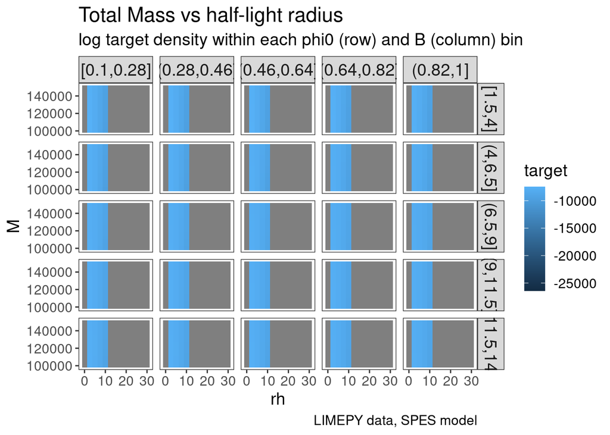

```r
library(ggplot2)
library(dplyr)

SPEStarget <- readRDS("../results/gridsearchSPES_2020-07-22")
# add the the dataframe
pargridSPES$target = SPEStarget

# replace -Inf with NAs for plotting purposes
pargridSPES$target <- na_if(x = pargridSPES$target, y = -Inf)

# for plotting as a conditional plot, place target values into 5 bins in g and 5 bins in phi0
conditional = mutate(pargridSPES, phi0bin = ggplot2::cut_interval(x = pargridSPES$phi0, n = 5) ) %>%
  mutate(Bbin = ggplot2::cut_interval(x = pargridSPES$B, n=5)) %>%
    mutate(etabin = ggplot2::cut_interval(x = pargridSPES$eta, n=5)) %>%
     group_by(M, rh, phi0bin, Bbin, etabin) %>% # then group by these bins, M, and r_h
      summarize(target = mean(target, na.rm = TRUE)) # and for every M and r_h, take the mean log target for every g and phi_0 combination

# make the base plot
g <- ggplot(conditional, aes(x=rh, y=M, fill=target)) +
  geom_raster()

# make a conditional plot by binning the results
g + facet_grid( phi0bin ~ Bbin ) + labs(title="Total Mass vs half-light radius", caption = "LIMEPY data, SPES model", subtitle="log target density within each phi0 (row) and B (column) bin") + theme_bw() + theme(strip.text = element_text(size = 14), text = element_text(size=14), panel.grid.major = element_blank(), panel.grid.minor = element_blank())
```

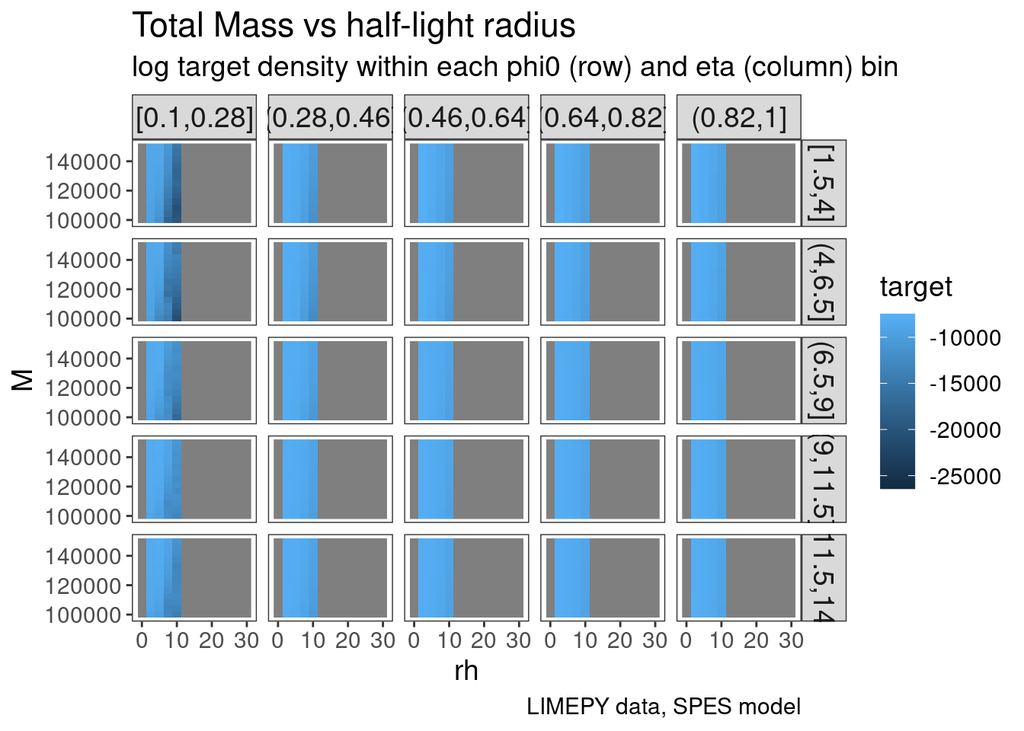

```r
g + facet_grid( phi0bin ~ etabin ) + labs(title="Total Mass vs half-light radius", caption = "LIMEPY data, SPES model", subtitle="log target density within each phi0 (row) and eta (column) bin") + theme_bw() + theme(strip.text = element_text(size = 14), text = element_text(size=14), panel.grid.major = element_blank(), panel.grid.minor = element_blank())
```

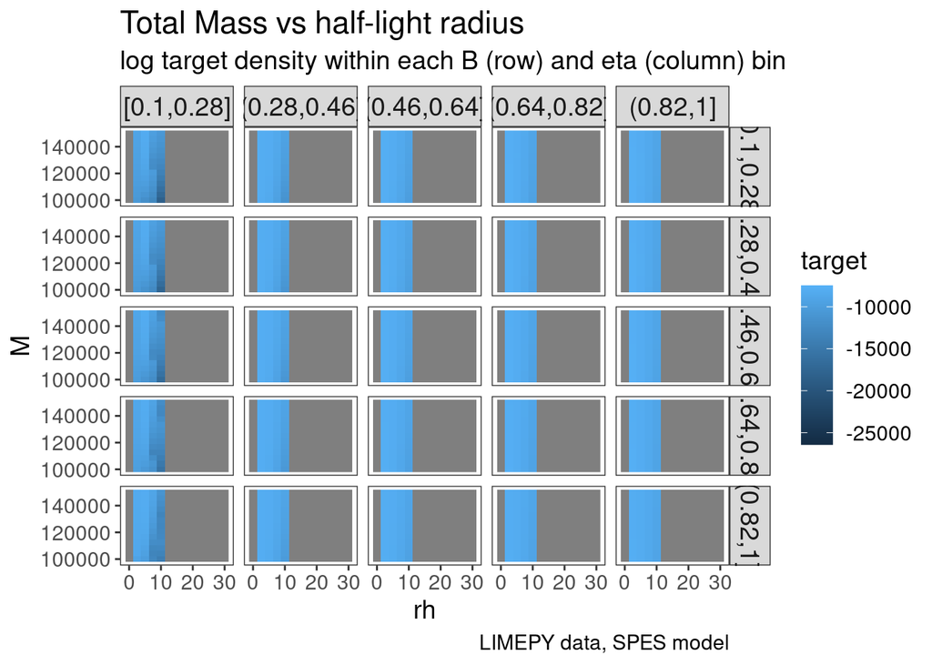

```r
g + facet_grid( Bbin ~ etabin ) + labs(title="Total Mass vs half-light radius", caption = "LIMEPY data, SPES model", subtitle="log target density within each B (row) and eta (column) bin") + theme_bw() + theme(strip.text = element_text(size = 14), text = element_text(size=14), panel.grid.major = element_blank(), panel.grid.minor = element_blank())
```